# 第8回 機械学習入門（多項式回帰と過学習）

経済データとプログラミングII

第8回

機械学習入門

多項式回帰と過学習

経済データとプログラミングII

第8回 — Topic01

多項式回帰

重回帰のまま、2 乗の列で曲線を引く

## 第8回の道のり

1

多項式回帰

実習：実行 データを読む準備

実習：写経 1 2 乗の列と重回帰

演習 8-1 2 乗の列の除外

2

過学習

実習：写経 2 E を隠した 5 人

3

次数の選択

実習：写経 3 訓練とテストの 36 年

実習：実行 次数の交差検証

演習 8-2 分割の数の変更

4

罰金と過学習

実習：実行 α の交差検証

実習：写経 4 選んだ α の採点

いまココ。曲がった並びを、**$x^2$ の列を足した重回帰**で表す

## このトピックで学ぶこと

- **ここまで**：自習時間をバイト日数で説明する、  
  まっすぐな線を引いてきた（重回帰）
- **でも**：バイトを 1〜2 日入れただけで自習がぐっと減り、  
  3 日を過ぎるともう減りにくい  
  そんな 5 人もいる。点が曲がって並ぶと、  
  まっすぐな線はある所でずっと外れる
- **問い**：曲がった並びを、式で表せないか
- **進め方**：前半は別の 5 人 K〜O の表。後半で 36 年の失業率と物価に同じ手順を

前の回は、過去の値をずらした列（ラグ）を作った  
今度は 2 乗した列を作る。道具は重回帰のまま

## 別の 5 人の直線

[figure not shown]

$R^2$ はいつもの 5 人 A〜E と同じ 0.80。でも残差の並び方に癖がある  
両端の K・O は線より上、間の L・M・N は線より下  
まっすぐな線のままでは、ある範囲でずっと外れる

## x² の列の追加

[figure not shown]

前の回は、過去の値を**ずらして**列を作った。今度は **2 乗して**列を作る  
前の重回帰はバイト日数とサークル日数。今度は 2 つめが $x^2$ の列  
**列さえ作れば、重回帰がそのまま使える**（係数も同じ最小二乗）

## ◼ 多項式回帰

定義

**多項式回帰**：$x$ の 2 乗・3 乗…の列を作って、説明変数に足した重回帰
$$\hat{y} = b_0 + b_1 x + b_2 x^2 + \cdots + b_d x^d$$

- **次数 $d$**：何乗の列まで足すか
- **今回は**：2 次 $\hat{y} = b_0 + b_1 x + b_2 x^2$  
  ことばでは：自習時間の見込み ＝ 切片 ＋ 係数 × バイト日数 ＋ 係数 × バイト日数²
- **心**：$x^2$ の列を足すと、$x$ が増えるにつれて傾きが変わる  
  だから曲がった並びを表せる

係数を掛けて足す形は重回帰と同じ  
横軸を $x$ だけにして描くと、$x^2$ の分で線が曲がる

## 別の 5 人の 2 次の曲線

[figure not shown]

見込みは 11.8・6.4・3.0・1.6・2.2  
例：L さん（2 日）$19.2 - 8.4 \times 2 + 1.0 \times 4 = 6.4$  
$R^2$ は直線の 0.80 から 0.994 へ

## よくある失敗 x の係数だけの読み

✕ 係数をそのまま読む

$x$ の係数は $-8.4$  
バイトが 1 日多いと、自習が 8.4 時間減る

○ 曲線の形で読む

$x$ を 1 増やすと、$x^2$ も一緒に動く  
1 → 2 日：$-8.4 + 1.0 \times 3 = -5.4$  
4 → 5 日：$-8.4 + 1.0 \times 9 = +0.6$

[figure not shown]

1 日ごとの差は $-5.4 \to -3.4 \to -1.4 \to +0.6$. **2 時間ずつ鈍る**（$x^2$ の係数 1.0 の 2 倍）  
$x$ と $x^2$ は似すぎ（VIF $26.7$）。係数を 1 つずつ読まず、曲線の形で読む

## データを読む準備のセル

今度は 36 年で、同じ手順を。写経せず、そのまま実行するセル（ノートの「実習：実行」）  
失業率：仕事が見つからない人の割合・コア物価上昇率：生鮮食品を除いた物価の 1 年の伸び

```python
!pip install -q japanize-matplotlib
import japanize_matplotlib
import pandas as pd
from sklearn.linear_model import LinearRegression
BASE = "ここに manaba の URL を貼る"
u = pd.read_csv(BASE + "unemployment_sa_monthly.csv", parse_dates=["date"])
c = pd.read_csv(BASE + "cpi_core_yoy_monthly.csv", parse_dates=["date"])
df = pd.merge(u, c, on="date").set_index("date")
df = df.resample("YS").mean()
print(len(df))
```

| 行 | 書き方 | 意味 |
| --- | --- | --- |
| 1-2 | 図の日本語 | Colab で日本語を出す 2 行（ノートで一度でよい） |
| 3-4 | 道具を呼ぶ | 表の道具と、最小二乗の回帰 `LinearRegression` |
| 5 | `BASE = "…"` | データの URL は manaba に載せている。**最後の / まで**を貼る |
| 6-10 | 読む・年平均 | 前に出てきた 36 年の表 `df`。36 と出る |

## 36 年の 2 次の曲線

[figure not shown]

物価上昇率の見込み ＝ 6.46 − 2.52 × 失業率 ＋ 0.224 × 失業率²  
失業率が低い所から上げると大きく下がり、高くなるほど下がり方が鈍る  
$R^2$ は直線の 0.544 から 0.567 へ

## 写経 1 2 乗の列と重回帰

```python
df["unemp2"] = df["unemployment_rate"] ** 2
X = df[["unemployment_rate", "unemp2"]]
y = df["cpi_core_yoy"]
m = LinearRegression()
m.fit(X, y)
print(m.coef_.round(3), m.intercept_.round(2))
print(round(m.score(X, y), 3))
```

| 行 | 部品 | 渡すもの | できるもの |
| --- | --- | --- | --- |
| 1 | **列を作る** `** 2` | 失業率の列 | 2 乗の列 `unemp2` （前の回は `shift` でずらした） |
| 2-3 | **入力と答え** | 説明変数 2 列の表 `X`・答えの列 `y` |  |
| 4-5 | **当てはめる** `.fit` | `X` と `y` | 二乗誤差の和が最小の係数 |
| 6-7 | **読む** `.coef_`・`.score` | 係数 2 つと切片・$R^2$ | `[-2.52 0.224] 6.46` と `0.567` |

## コードセルの写経と実行

1. **＋ コード**で空のセルを足す  
   （案内の文の下）
2. 写経 1 の 7 行を上  
   から写す
3. **▶** か **Shift + Enter** で実行  
   （Mac は Shift + return）
4. 係数と $R^2$ の 0.567 を見る

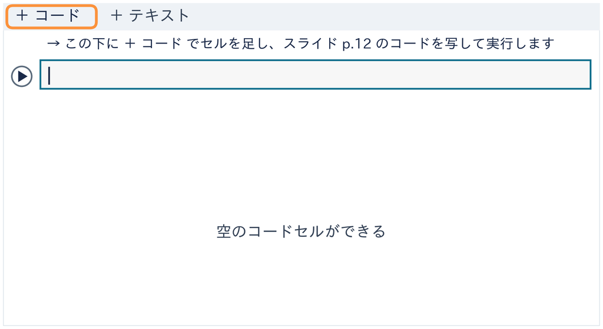

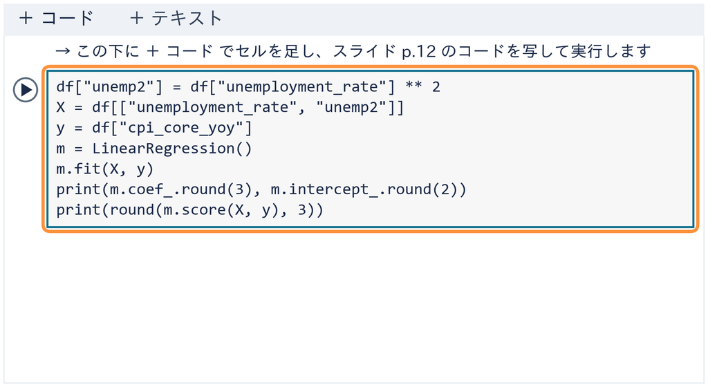

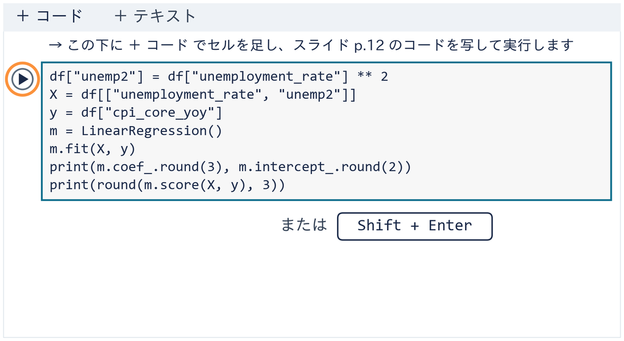

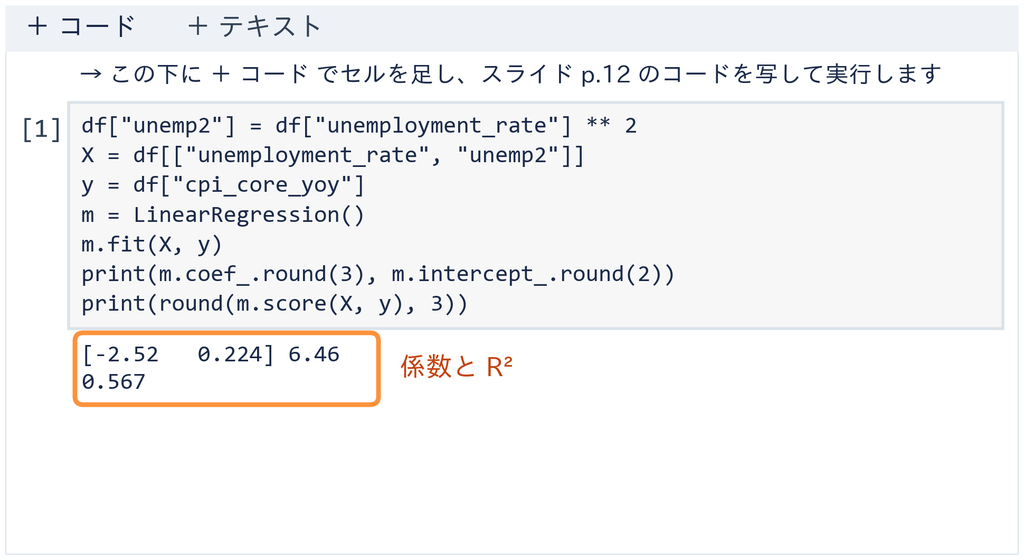

⏸ PAUSE 動画を止めて $2$ 分。`0.567` が出たら再生に戻る

## 演習 8-1 2 乗の列の除外

演習 8-1

2 乗の列 `unemp2` を外すと、手元の $R^2$ は

```python
X = df[["unemployment_rate"]]
```

1. **先に考える**：ⓐ 上がる ⓑ 下がる ⓒ 同じ
2. **写して変える**：写経 1 の 2〜7 行を新しいセルに写し、`X` の行から `"unemp2"` を消す
3. **終わり**：答え欄に ⓐ〜ⓒ と、出た $R^2$

⏸ PAUSE 動画を止めて $3$ 分。答えを書いたら再生に戻る

## 演習 8-1 の答え

答えは **ⓑ 下がる**。$R^2$ は 0.567 から 0.544 へ  
出力は `[-0.859] 3.61` と `0.544`

前に出てきた定理 1

変数を足しても $R^2$ は下がらない

外すと上がらないのは、定理 1 の裏返し（今回は下がった）  
列を足しても、手元の点への $R^2$ は下がらない

## まとめ

- 2 乗の列を作れば、曲がった並びも重回帰で表せる（**多項式回帰**）
- 係数を 1 つずつ読まず、1 日ごとの差のように曲線の形で読む
- 列を足しても、手元の $R^2$ は下がらない（今回は 0.544 → 0.567）

2 乗の列で、曲がった並びに曲線を引けた  
残った問い：10 次まで足せば、  
見ていない相手にも当たるか。これを次のトピックで見る

経済データとプログラミングII

第8回 — Topic02

過学習

曲げすぎると、手元の点を丸暗記して見ていない相手で外れる

## 第8回の道のり

1

多項式回帰

実習：実行 データを読む準備

実習：写経 1 2 乗の列と重回帰

演習 8-1 2 乗の列の除外

2

過学習

実習：写経 2 E を隠した 5 人

3

次数の選択

実習：写経 3 訓練とテストの 36 年

実習：実行 次数の交差検証

演習 8-2 分割の数の変更

4

罰金と過学習

実習：実行 α の交差検証

実習：写経 4 選んだ α の採点

いまココ。曲げるほど、見ていない相手にも当たるか

## このトピックで学ぶこと

- **ここまで**：2 乗の列を足すと、手元の $R^2$ は 0.544 から 0.567 に上がった  
  列を足しても、手元の $R^2$ は下がらない（上がることが多い）
- **でも**：来年の物価を見込みたい人が知りたいのは  
  手元の点に合うかではなく、見ていない相手に当たるか
- **問い**：次数を上げて曲げるほど、見ていない相手にも当たるか
- **進め方**：前に出てきた「1 人を隠して確かめる」手順を、次数を変えて使う  
  前半はいつもの 5 人 A〜E。後半で 36 年の失業率と物価に同じ手順を

使える場面：「AI の予測精度 95%」と聞いたら、何で測ったかを聞く

## ✋ たしかめ いつもの 5 人の 2 次

たしかめ

A〜E に $x^2$ を説明変数として足すと、線はどうなるか

| 人 | A | B | C | D | E |
| --- | --- | --- | --- | --- | --- |
| バイト日数 $x$ | 1 | 2 | 3 | 4 | 5 |
| $x^2$ | 1 | 4 | 9 | 16 | 25 |
| 自習時間 $y$ | 9 | 10 | 6 | 2 | 3 |

1. **ⓐ** 山の形に曲がる **ⓑ** 直線のまま **ⓒ** 谷の形に曲がる
2. 予想の材料：5 人は直線のまわりに、上下にばらついている

⏸ PAUSE 動画を止めて $1$ 分。選んだら再生に戻る

## たしかめの答え

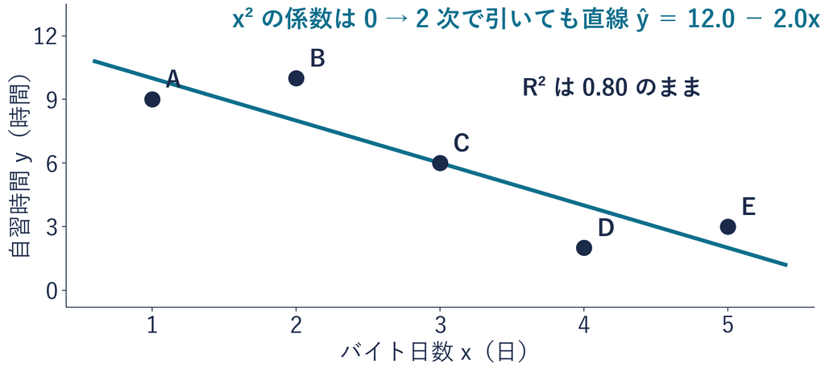

答えは **ⓑ 直線のまま**。$x^2$ の係数は 0  
曲げるかどうかは、データが決める  
では、E さんを隠して 4 人だけで 2 次を引くと

## ◼ 次数を上げる道具

前のトピックでは $x^2$ の列を手で作った。  
10 次まで手で作るのは大変なので、列を作る道具を使う

[figure not shown]

**次数** ＝ $x$ を何乗まで列に足すか。10 次なら列は 10 本

## ◼ 隠して確かめる手順

前に、E さんを隠して、係数を決めるのに使っていない人への当たりを確かめた  
同じ手順で、今度は次数を変える

手順

STEP 1隠す 1 点を決める

STEP 2残りの点で、列を足して当てはめる

STEP 3残りの点への当てはまり $R^2$ を読む

STEP 4隠した点を線で予測し、実際と比べる

次のページから、いつもの 5 人の表で E さんを隠す

## STEP 1〜3：4 人で学ぶ 1 次と 2 次

[figure not shown]

4 人への当てはまりは 0.806 → 0.968 に上がった。では、隠した E さんは

## STEP 4：隠した E さんの予測

[figure not shown]

2 次は −5.75 時間と答えた。実際は 3 時間。1 次の 0.5 よりずっと外れる

手元の $R^2$ が高いことと、見ていない相手に当たることは別

4 人では調整済み $R^2$ も 1 次 0.710 → 2 次 0.903 と上がる。これも手元の点だけで測った数

## ◼ 過学習

定義

**過学習** ＝ 手元の点の**細かい上下まで合わせすぎて**、  
見ていない点で外すこと

全部の点を通らなくても起きる。2 次は 4 人を通っていないのに外した

✕ 過去問を丸暗記した学生

同じ問題なら満点

初めて見る問題で崩れる

○ 解き方を学んだ学生

過去問も、初めての問題も解ける

覚えたのは答えではなく手順

手元の $R^2$ だけでは見えない。隠した点で確かめる

## デモ：曲げすぎの実験室

数の話

$\hat{y} = b_0 + b_1 x + \cdots + b_d x^d$（次数 $d$ まで列を足す）

- **何を見るか**：今度は 36 年の表で、同じことを。  
  次数を上げると曲線は点に寄る。隠した 1 年は当たるのか
- **図の意味**：左に散布図と曲線。右に $R^2$ と 1991 年の外れ
- **操作**：タブ 3 つ（1・3・10 次）、次数のつまみ、1991 年を隠す、戻す

ミッション 予想を決めてから「1991 年を隠す」—  
1・3・10 次のどれがいちばん外れる？

※ 次のスライドへ進むときは、デモの枠の外を一度クリックしてから ← → キーを押す

[interactive chart not shown]

## ★ 隠した 1991 年の予測

1991 年を隠し、残り 35 年で 1・3・10 次の曲線を引いて、1991 年を予測する

[figure not shown]

隠した 1991 年の実測は +2.88%。10 次は +8.49% と予測した

## ★ 次数ごとのあてはまりと残差

35 年への $R^2$ に、前に出てきた調整済み $R^2$ を並べる

[figure not shown]

10 次は $R^2$ も調整済み $R^2$ も最高。なのに 1991 年の残差も最大の 5.61

## よくある失敗 調整済み決定係数の過信

✕ 調整済み $R^2$ が最高の次数を選ぶ

足した分を割り引いても  
上がるかを見る数と習った

35 年では $10$ 次の $0.733$ が最高

○ 見ていないデータで確かめる

$10$ 次は 1991 年を $5.61$ 外した

$3$ 次の外れは $0.18$

4 人のときと同じ：調整済み $R^2$ も、手元の点だけで測った数  
見ていないデータへの当たりは、分けて測る

## 写経 2 E を隠した 5 人の表

```python
from sklearn.preprocessing import PolynomialFeatures
from sklearn.pipeline import make_pipeline
d = pd.DataFrame({"人": ["A", "B", "C", "D", "E"],
                  "x": [1, 2, 3, 4, 5],
                  "y": [9, 10, 6, 2, 3]})
X, y = d[["x"]], d["y"]
keep, hide = d["人"] != "E", d["人"] == "E"
for k in [1, 2]:
    m = make_pipeline(PolynomialFeatures(k, include_bias=False),
                      LinearRegression())
    m.fit(X[keep], y[keep])
    r2 = m.score(X[keep], y[keep])
    print(k, round(r2, 3), m.predict(X[hide]).round(2))
```

| 行 | 部品 | 意味 |
| --- | --- | --- |
| 1-2 | **道具を呼ぶ** | 列を作る `PolynomialFeatures`・道具をつなぐ `make_pipeline`（前に出てきた） |
| 3-6 | **表を作り、分ける** | 入力 `X` は `[["x"]]`（表の形）・答え `y` は 1 列 |
| 7 | **STEP 1 隠す人** | `!=` 違う・`==` 同じ。`X[keep]` で True の行だけ |
| 8-11 | **STEP 2 当てはめる** | $x$ の `k` 乗までの列を作り、最小二乗で係数を求める `include_bias=False` ＝ 定数の列は足さない |
| 12-13 | **STEP 3・4** `.score`・`.predict` | `1 0.806 [0.5]`・`2 0.968 [-5.75]` |

## コードセルの写経と実行

1. **＋ コード**で空のセルを足す  
   （案内の文の下）
2. 写経 2 の 13 行を上  
   から写す
3. **▶** か **Shift + Enter** で実行  
   （Mac は Shift + return）
4. 2 行の出力（4 人の $R^2$ と  
   E さんの予測）を見る

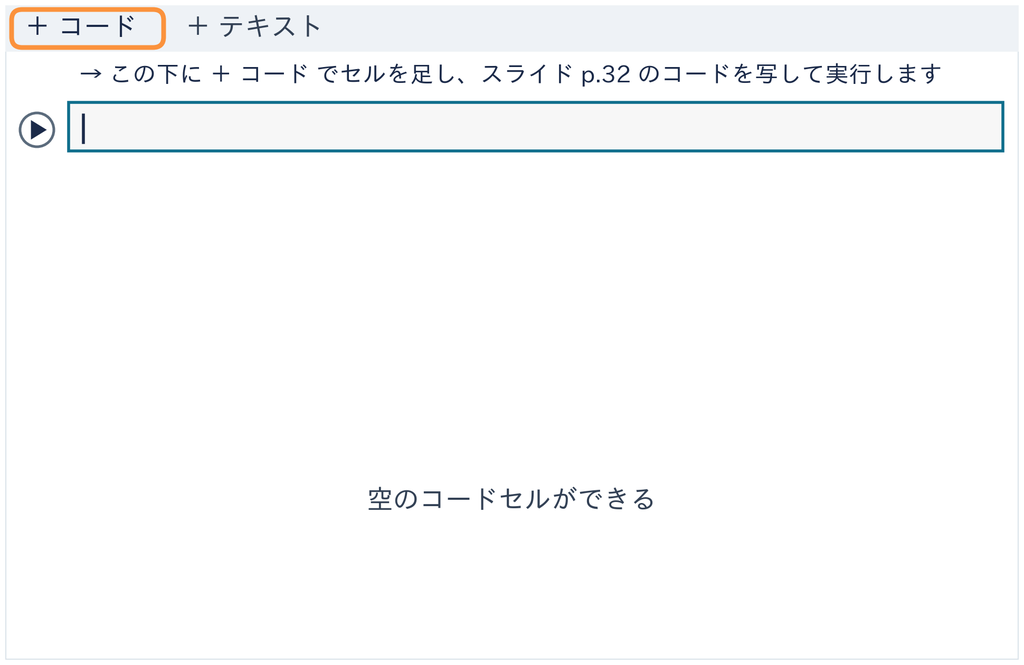

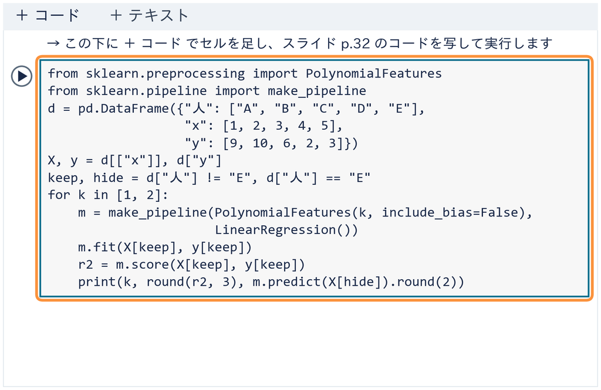

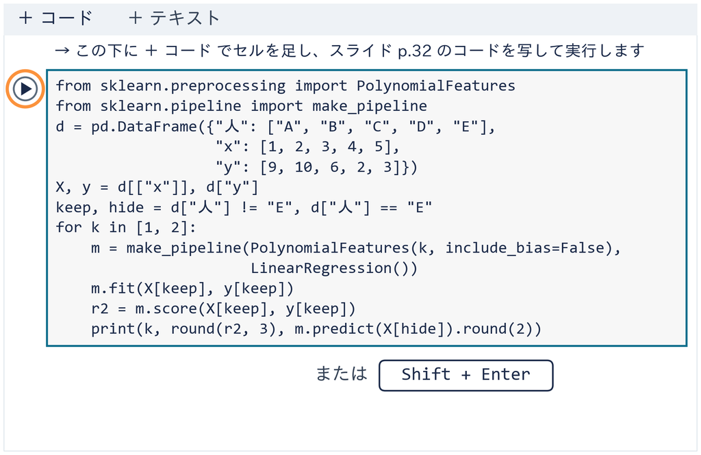

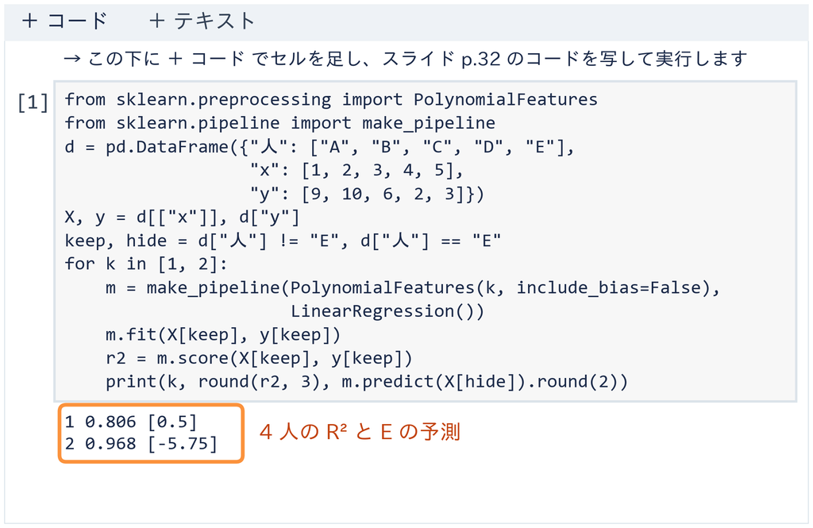

⏸ PAUSE 動画を止めて $2$ 分。2 行出たら再生に戻る

## まとめ

- `PolynomialFeatures` で $x^2, x^3, \dots$ の列を作る  
  係数は同じ最小二乗で求める
- 曲げすぎると見ていない相手で外れる（**過学習**）  
  E さんを −5.75 時間、1991 年を +8.49% と予測した
- 手元の $R^2$ も調整済み $R^2$ も、見ていない相手への当たりは測らない

曲げすぎると、見ていない相手で外れると分かった  
残った問い：1 人・1 年を隠す比べは、隠す相手しだい  
（E さんも 1991 年も端の点）。では、次数はどう選ぶか  
これを次のトピックで見る

経済データとプログラミングII

第8回 — Topic03

モデル選択と交差検証

次数も、見ていないデータへの当たり（CV の誤差）で選ぶ

## 第8回の道のり

1

多項式回帰

実習：実行 データを読む準備

実習：写経 1 2 乗の列と重回帰

演習 8-1 2 乗の列の除外

2

過学習

実習：写経 2 E を隠した 5 人

3

次数の選択

実習：写経 3 訓練とテストの 36 年

実習：実行 次数の交差検証

演習 8-2 分割の数の変更

4

罰金と過学習

実習：実行 α の交差検証

実習：写経 4 選んだ α の採点

いまココ。次数は、何で決めるか

## このトピックで学ぶこと

- **ここまで**：1 人・1 年を隠すと、曲げすぎが見えた  
  E さんを −5.75 時間、1991 年を +8.49% と予測した
- **でも**：隠したのは 1 人・1 年だけで、どちらも端の点  
  隠す相手を替えれば、結果も変わるかもしれない
- **問い**：次数は、何で決めればよいか
- **進め方**：前に出てきた訓練とテスト・交差検証を、次数を選ぶのに使う  
  前半はいつもの 5 人 A〜E。後半で 36 年の失業率と物価に同じ手順を

**モデル選択** ＝ 候補の式（ここでは次数）の中から 1 つを選ぶこと

使える場面：ゼミや卒論で回帰の次数や変数の数を決めるとき  
手元の $R^2$ ではなく、見ていないデータへの当たりで選ぶ

## ◼ 訓練データとテストデータ

前のトピックで E さんを隠したのは、5 人を訓練 4 人とテスト 1 人に分けたこと

定義

**訓練データ**＝ 係数を決めるのに使う分（A〜D の 4 人）

**テストデータ**＝ 最後まで触らずに、採点だけに使う分（E さん）

- **掟は 1 つ**：テストは、係数を決めるのにも、次数を選ぶのにも使わない
- **型**：係数は訓練で求める → 次数も訓練の中だけで選ぶ（次のページ）  
  → 最後にテストで 1 回だけ採点する
- **この回では**：仕組みを見るため、同じテストで並べることがある

一度でも見たデータは、もう「見ていないデータ」ではない

## ◼ 交差検証の手順

前に出てきた交差検証では、罰金の強さを選んだ。同じ手順で、今度は次数を選ぶ

手順

STEP 1候補の次数を並べる

STEP 2訓練を $K$ 個に分け、交代で 1 つを検証用にして $K$ 回測る

STEP 3CV の誤差がいちばん小さい次数を選ぶ

STEP 4選んだ次数で訓練全体に学ばせ、テストを 1 回だけ採点する

- **検証用** ＝ 次数を選ぶために、訓練の中から当てさせる分（テストとは別）
- **CV の誤差** ＝ 検証用での残差の二乗の平均を、$K$ 回ぶん平均した数  
  小さいほどよく当たる（CV は交差検証の英語の頭文字）

次のページから、5 人で STEP 1〜3 を進める。候補は 1 次と 2 次

## STEP 2：1 人ずつ交代する検証用

5 人を 5 つに分けると 1 人ずつ。交代で 1 人を検証用にし、残り 4 人で線を引いて当てる

[figure not shown]

1 回目は B〜E で $\hat{y} = 14 - 2.5x$ を引き、A さんの $x = 1$ を入れる  
$14 - 2.5 \times 1 = 11.5$。実際の 9 との差を二乗して 6.25

5 人の例ではテストを取らず、5 人全員で交代する。予測は小数第 2 位に丸めた値

## STEP 2・3：平均の比較と選択

**今回は** 5 回の残差の二乗を足して 5 で割る

1 次

$(6.25 + 8.16 + 0 + 8.16 + 6.25) \div 5$

$\approx 5.77$

STEP 2 の左の列

2 次

$(76.56 + 10.12 + 0 + 10.12 + 76.56) \div 5$

$\approx 34.67$

STEP 2 の右の列

小さいのは 1 次。STEP 3 で 1 次を選ぶ

8.16 などは丸めた値。平均は丸める前の値から出した

## 訓練とテストの無作為分割

今度は 36 年の表で、同じ手順を。くじで 36 × 0.25 ＝ 9 年をテストに

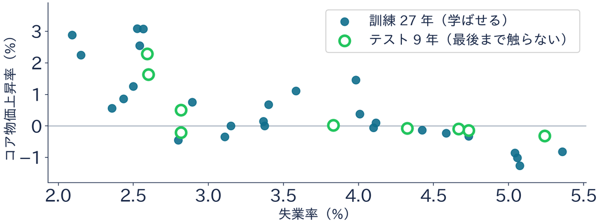

白抜きの 9 年がテスト。係数を決めるのは残りの 27 年だけ  
年を混ぜて分けた。隠した年への当たりで、過去だけで先の年を当てる評価とは別

## ★ 訓練とテストの決定係数

**乖離** ＝ 訓練の $R^2$ − テストの $R^2$  
手元での当たりと、見ていない年での当たりの差。大きいほど丸暗記を疑う

[figure not shown]

手元で最高の 10 次は、テストで 0.422。3 次の 0.521 より低い  
ただし、この分け方 1 回の結果。1 回の差だけでは決めない

## 写経 3 訓練とテストに分けた 36 年

```python
from sklearn.model_selection import train_test_split
X, y = df[["unemployment_rate"]], df["cpi_core_yoy"]
Xtr, Xte, ytr, yte = train_test_split(X, y, test_size=0.25,
                                      random_state=42)
for k in [1, 3, 10]:
    m = make_pipeline(PolynomialFeatures(k, include_bias=False),
                      LinearRegression())
    m.fit(Xtr, ytr)
    print(k, round(m.score(Xtr, ytr), 3),
          round(m.score(Xte, yte), 3))
```

| 行 | 部品 | 意味 |
| --- | --- | --- |
| 1-2 | **道具と表** | 分ける道具 `train_test_split`・36 年の失業率 `X` と物価 `y` |
| 3-4 | **分ける** | 4 分の 1 をテストに・くじの番号 42 → 訓練 `Xtr` `ytr`・テスト `Xte` `yte` |
| 5-8 | **訓練だけで** `.fit` | 1・3・10 次の曲線を、訓練の 27 年だけで求める |
| 9-10 | **2 回採点** `.score` | 訓練とテストの $R^2$ → `1 0.564 0.378` … `10 0.808 0.422` |

※ `tr` は訓練（train）・`te` はテスト（test）  
※ `for` の下の字下げがずれると `IndentationError`

## コードセルの写経と実行

1. **＋ コード**で空のセルを足す  
   （案内の文の下）
2. 写経 3 の 10 行を上  
   から写す
3. **▶** か **Shift + Enter** で実行  
   （Mac は Shift + return）
4. 3 行の出力  
   （次数・訓練の $R^2$・  
   テストの $R^2$）を見る

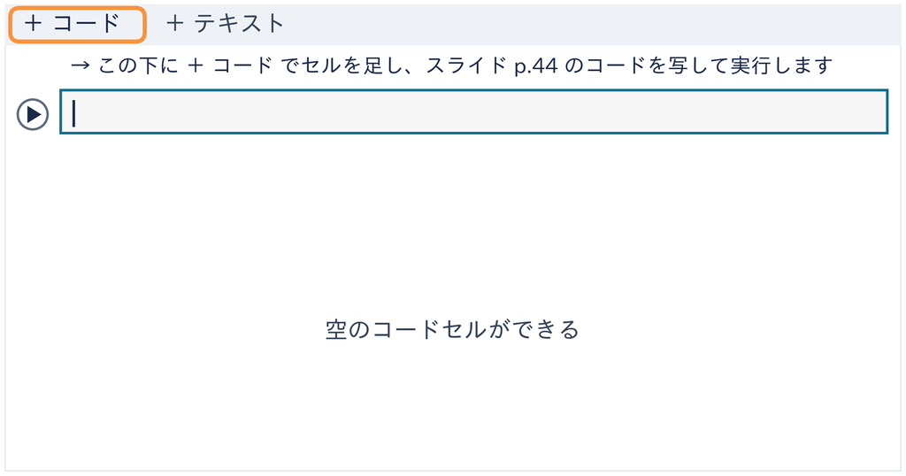

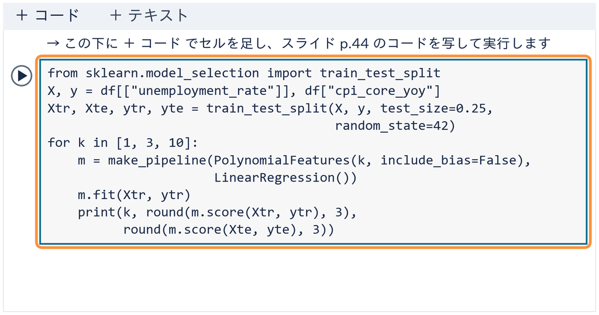

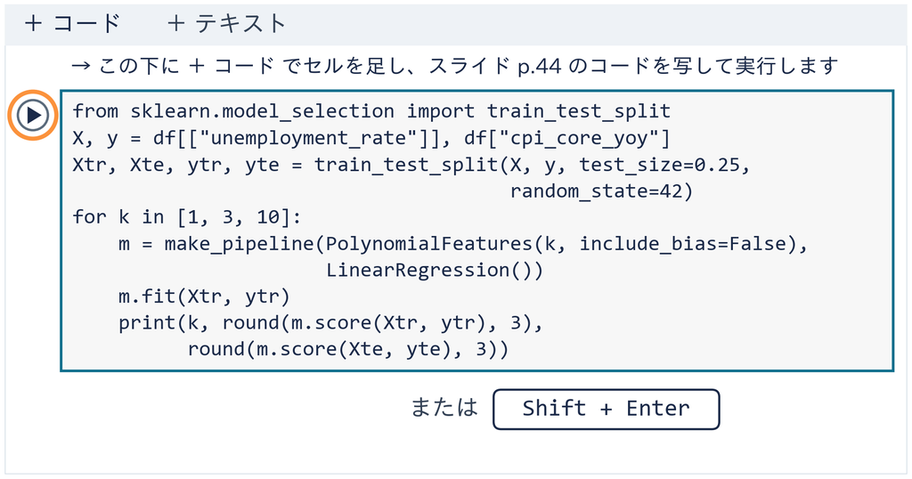

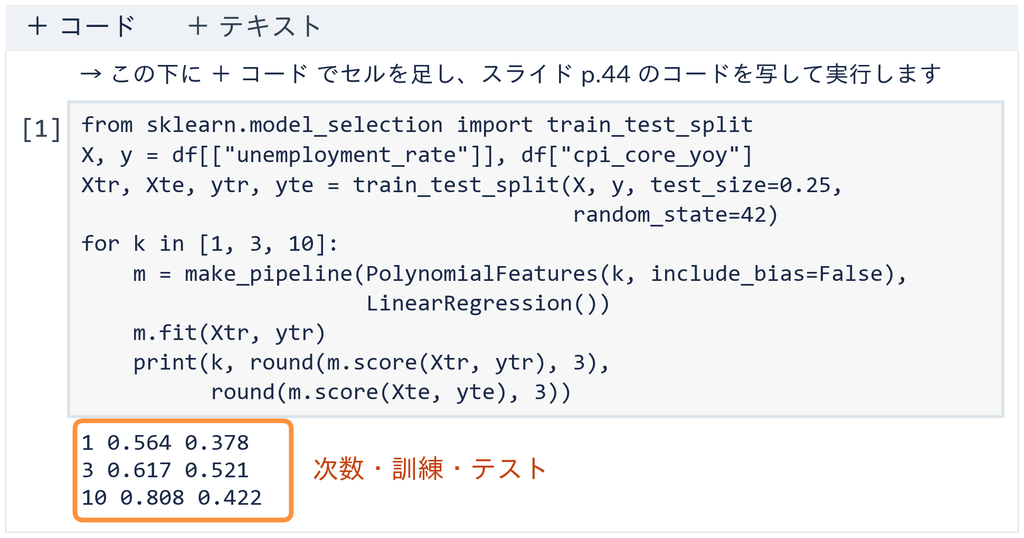

⏸ PAUSE 動画を止めて $2$ 分。3 行出たら再生に戻る

## ★ 交差検証の誤差と次数

訓練 27 年を 6・6・5・5・5 年の 5 つに分け、1〜10 次の CV の誤差を測る  
縦軸は 1 目盛りで 10 倍

[figure not shown]

この分け方では 3 次を選ぶ。次数も、罰金の強さと同じ CV の誤差で選べる

## 次数の候補と交差検証のコード

写経せず、そのまま実行するセル（ノートの「実行」の節）。STEP 1〜4 を 1 つのセルで

```python
from sklearn.model_selection import KFold, cross_val_score
kf = KFold(5, shuffle=True, random_state=42)
cv = []
for d in range(1, 11):
    m = make_pipeline(PolynomialFeatures(d, include_bias=False),
                      LinearRegression())
    s = cross_val_score(m, Xtr, ytr, cv=kf,
                        scoring="neg_mean_squared_error")
    cv.append(-s.mean())
best_d = cv.index(min(cv)) + 1
m = make_pipeline(PolynomialFeatures(best_d, include_bias=False),
                  LinearRegression())
m.fit(Xtr, ytr)
print(best_d, round(m.score(Xte, yte), 3))
```

| 行 | 部品 | 意味 |
| --- | --- | --- |
| 1-2 | **分け方** | 訓練を混ぜて 5 つに分ける `KFold`・測る `cross_val_score` |
| 3-4 | **STEP 1：候補** | `cv` は誤差を入れる箱・`range(1, 11)` は 1〜10 次 |
| 5-9 | **STEP 2：5 回測る** | 1 つの次数で 5 回測り、平均を `cv` へ（`neg_` は符号が逆なので `-`） |
| 10 | **STEP 3：最小の次数** | いちばん小さい位置は 0 から数えるので `+ 1` → `best_d` |
| 11-14 | **STEP 4：テスト 1 回** | 選んだ次数で訓練全体に学ばせ、テストを採点 → `3 0.521` |

## 演習 8-2 分割の数の変更

演習 8-2

訓練を 5 つではなく 10 に分けると、選ぶ次数は

```python
from sklearn.model_selection import KFold, cross_val_score
kf = KFold(10, shuffle=True, random_state=42)
```

1. **先に考える**：ⓐ 3 次のまま ⓑ 変わる
2. **写して変える**：**＋ コード** で新しいセルを足し、  
   実行のセルの 14 行を写す  
   2 行目の `5` を `10` に（1 か所）。元の実行のセルはそのまま
3. **終わり**：答え欄に ⓐ か ⓑ と、出た次数とテストの $R^2$

⏸ PAUSE 動画を止めて $3$ 分。答えを書いたら再生に戻る

## 演習 8-2 の答え

答えは **ⓑ 変わる**。10 に分けると 1 次を選ぶ。出力は `1 0.378`

| 分ける数 | 選ぶ次数 | その次数の CV の誤差 | テストの $R^2$ |
| --- | --- | --- | --- |
| 5 | 3 次 | 0.780 | 0.521 |
| 10 | 1 次 | 0.670 | 0.378 |

1〜5 次は CV の誤差の差が小さく、分け方で入れ替わる  
7 次以上はまず選ばれない（くじを 100 通り変えて 2 回）

テストの 0.378 を見て 5 に戻すのは、テストで次数を選ぶのと同じ（反則）

## まとめ

- 次数は、訓練の中で交差検証して、CV の誤差で選ぶ  
  テストは最後に 1 回だけ採点する
- 5 人では 1 次（5.77 ＜ 34.67）。36 年ではこの分け方で 3 次
- 1〜5 次は僅差で、分け方しだい。  
  曲げすぎた 7 次以上はまず選ばれない

次数は CV の誤差で選べると分かった  
残った問い：次数を下げると、高い次の列はまるごと捨てる  
列を残したまま、曲げすぎだけ抑えられないか  
これを次のトピックで見る

経済データとプログラミングII

第8回 — Topic04

正則化と過学習

似すぎを抑えた罰金が、曲げすぎも抑える

## 第8回の道のり

1

多項式回帰

実習：実行 データを読む準備

実習：写経 1 2 乗の列と重回帰

演習 8-1 2 乗の列の除外

2

過学習

実習：写経 2 E を隠した 5 人

3

次数の選択

実習：写経 3 訓練とテストの 36 年

実習：実行 次数の交差検証

演習 8-2 分割の数の変更

4

罰金と過学習

実習：実行 α の交差検証

実習：写経 4 選んだ α の採点

いまココ。列を残したまま、曲げすぎを抑える

## このトピックで学ぶこと

曲げすぎの対処は 2 つ  
① 次数を下げる：前のトピック ② 高い次の列を残して、  
罰金で抑える：このトピック

- **ここまで**：次数は交差検証で選べた。この分け方では 3 次（テスト 0.521）
- **でも**：次数を下げると、高い次の列はまるごと捨てる  
  前に出てきた罰金は、似すぎた列を残したまま、係数の暴れを抑えた
- **問い**：高い次の列を残したまま、曲げすぎだけ抑えられないか
- **進め方**：10 次を固定して、罰金の強さ $\alpha$ を交差検証で選ぶ  
  前半はいつもの 5 人の $x$ と $x^2$。後半で 36 年の 10 次に

どちらの対処も正しい道。最後に、同じ分け方で 2 つを比べる  
使える場面：ゼミや卒論で説明に使う列が多いとき、捨てずに罰金で抑える道もある

## STEP 1・2：平均を引いた列

罰金は係数の大きさを見る。だから先に**標準化**で目盛りをそろえる  
$z = (x - \text{平均}) \div \text{標準偏差}$：STEP 1 平均 → 2 引く → 3 標準偏差 → 4 割る

[figure not shown]

平均は $x$ が (1+2+3+4+5)÷5 ＝ 3。$x^2$ が (1+4+9+16+25)÷5 ＝ 11

## STEP 3：2 つの列の標準偏差

**今回は** 引いた値を二乗して平均し、平方根をとる

| 列 | 引いた値 | 二乗して平均 | 標準偏差 |
| --- | --- | --- | --- |
| $x$ の列 | $-2, -1, 0, 1, 2$ | $(4 + 1 + 0 + 1 + 4) \div 5 = 2$ | $\sqrt{2} \approx 1.41$ |
| $x^2$ の列 | $-10, -7, -2, 5, 14$ | $(100 + 49 + 4 + 25 + 196) \div 5 = 74.8$ | $\sqrt{74.8} \approx 8.65$ |

$x^2$ の列のばらつきは、$x$ の列の約 6 倍

## STEP 4：標準偏差で割った列

[figure not shown]

どちらの列も、平均 0・ばらつき 1 の同じ目盛りに

## 4 人の 2 次に足す罰金

E さんを隠した A〜D の 2 次（$x$ と $x^2$ は標準化）  
罰金なしの係数は 4.19 と −7.10。大きく、向きが逆で打ち消し合う  
最小にするもの：二乗誤差の和 ＋ $\alpha$ × 罰金（係数の二乗の和）

| 候補 | 係数（$x$・$x^2$） | 二乗誤差の和 | 罰金（$\alpha = 1$） | 合計 |
| --- | --- | --- | --- | --- |
| ① 罰金なし | 4.19・−7.10 | 1.25 | $4.19^2 + 7.10^2 \approx 67.97$ | 69.22 |
| ② $\alpha = 1$ | −0.96・−1.62 | 5.20 | $0.96^2 + 1.62^2 \approx 3.55$ | 8.75 |

罰金なしなら ① が勝つ（1.25 ＜ 5.20）。罰金を足すと ② が勝つ（8.75 ＜ 69.22）  
罰金は、大きな係数の組を負けさせる。だから係数は 0 の側へ縮む

## 罰金の強さと E さんの予測

同じ 4 人で $\alpha$ を変え、隠した E さん（$x = 5$）を予測する

[figure not shown]

$\alpha$ を上げると係数が縮み、曲がりがなだらかに。E さんへの外れは小さくなる  
強すぎると（100）4 人の平均 6.75 の平らな線に近づき、また外れる

## ★ 係数の大きさと過学習

今度は 36 年の表。次数ごとに係数の大きさの最大を比べる（標準化なしの値）

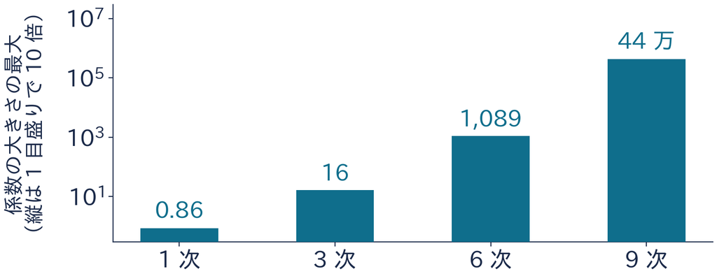

1 次 0.86 → 9 次 44 万。曲げすぎた曲線は、大きな係数で点を追いかけている  
曲げすぎかは見ていない年への誤差で決める。係数の大きさはその手がかり  
だから：係数が大きいほど罰金（係数の二乗の和）を払わせて、  
点を追うのをほどほどで止める

## ★ 罰金の強さと 10 次の係数

36 年の 10 次（標準化つき）を訓練 27 年で学ぶ。$\alpha$ を 1 つずつ決めて見比べる

| $\alpha$ | 係数の大きさの 最大（標準化後） | 訓練 $R^2$ | テスト $R^2$ |
| --- | --- | --- | --- |
| $0$（罰金なし） | 2.7 億 | 0.808 | 0.422 |
| $0.0001$ | 17 | 0.647 | 0.518 |
| $0.01$ | 4.6 | 0.620 | 0.512 |
| $100$ | 0.096 | 0.439 | 0.371 |

$\alpha$ を上げると係数は縮む。強すぎると（100）曲がりまで失い、罰金なしより下がる

テストを並べたのは仕組みを見るため。$\alpha$ を選ぶのは交差検証（この後）  
2.7 億は標準化した後の値。似た列どうしで大きな係数が打ち消し合う（44 万とは比べない）

## 罰金による曲線の変化

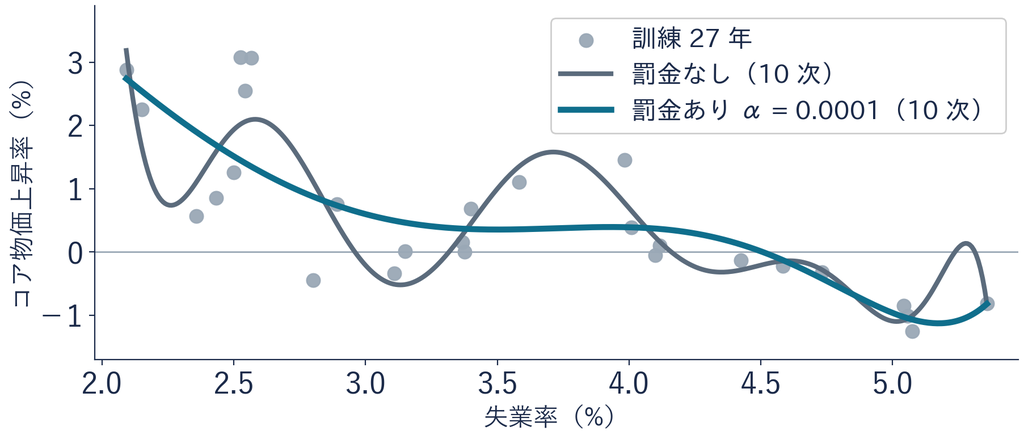

どちらも 10 次。罰金をつけると曲線はなだらかになり、テストの $R^2$ は 0.422 → 0.518

## デモ：罰金の実験室

数の話

$\min \sum (y_i - \hat{y}_i)^2 + \alpha \times$ 罰金（$\alpha$ は罰金の強さ）

- **何を見るか**：10 次を固定して、$\alpha$ だけを動かす。  
  $\alpha$ を上げると係数は縮む。CV の誤差の谷はどこか
- **図の意味**：上は散布図と 10 次の曲線、左下は係数の大きさ（縦は対数）、  
  右下は CV 誤差の曲線、右は CV 誤差とゼロの係数の本数
- **操作**：タブ 3 つ（罰金なし・Ridge・Lasso）、$\alpha$ のつまみ、CV の谷へ飛ぶ、戻す

ミッション いちばん良い α は 大きい／小さい／中間？  
予想してから「CV の谷へ飛ぶ」

※ 次のスライドへ進むときは、デモの枠の外を一度クリックしてから ← → キーを押す

[interactive chart not shown]

## 罰金の強さの候補と交差検証のコード

```python
import numpy as np
from sklearn.linear_model import Ridge
from sklearn.preprocessing import StandardScaler
alphas = np.logspace(-4, 3, 20)
kf = KFold(5, shuffle=True, random_state=42)
cv = []
for a in alphas:
    m = make_pipeline(PolynomialFeatures(10, include_bias=False),
                      StandardScaler(), Ridge(alpha=a))
    s = cross_val_score(m, Xtr, ytr, cv=kf,
                        scoring="neg_mean_squared_error")
    cv.append(-s.mean())
best = alphas[np.argmin(cv)]
print(best)
```

| 行 | 部品 | 意味 |
| --- | --- | --- |
| 1-3 | **道具を呼ぶ** | 数の道具 `np`・罰金つきの回帰 `Ridge`・標準化 `StandardScaler` |
| 4 | **STEP 1：候補** | 10 の −4 乗から 3 乗まで、同じ倍率で 20 個 → `alphas` |
| 5-6 | **分け方と箱** | 訓練を 5 つに分け直す（演習 8-2 で 10 にしたため）・誤差を入れる箱 `cv` |
| 7-9 | **繰り返しと模型** | 7 行目 `for` で候補を 1 つずつ `a` へ。次数は 10 で固定・標準化 → `Ridge`。 次数のコードと違うのは候補と模型の 2 か所 |
| 10-12 | **STEP 2：5 回測る** | 1 つの $\alpha$ で 5 回測り、平均を `cv` へ |
| 13-14 | **STEP 3：最小の候補** | `np.argmin`：いちばん小さい位置 → `best`（約 0.00023） |

## 写経 4 選んだ $\alpha$ でのテストの採点

```python
m = make_pipeline(PolynomialFeatures(10, include_bias=False),
                  StandardScaler(), Ridge(alpha=best))
m.fit(Xtr, ytr)
print(round(m.score(Xte, yte), 3))
```

| 行 | 部品 | 渡すもの | できるもの |
| --- | --- | --- | --- |
| 1-2 | **STEP 4：選んだ候補** | 前のページの `best` | 模型 `m` |
| 3 | **訓練全体で学ぶ** | 訓練の 27 年 |  |
| 4 | **テストを 1 回だけ採点** | テストの 9 年 | `0.517` |

※ 係数は訓練で求める → $\alpha$ は交差検証で選ぶ → 最後にテストで 1 回だけ採点する  
※ 次数を選んだときと同じ型

## コードセルの写経と実行

1. **＋ コード**で空のセルを足す  
   （案内の文の下）
2. 写経 4 の 4 行を  
   上から写す
3. **▶** か **Shift + Enter** で実行  
   （Mac は Shift + return）
4. テストの $R^2$  
   `0.517` を見る

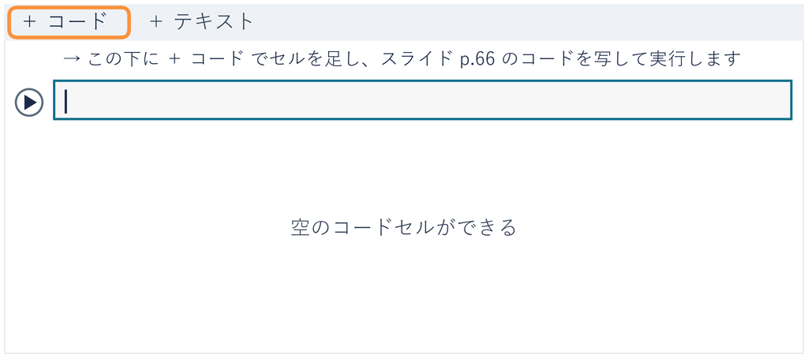

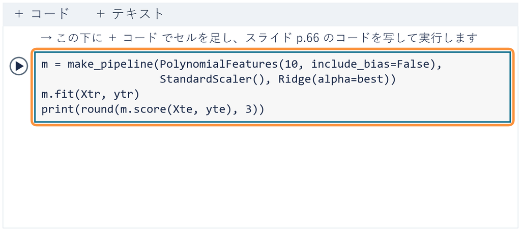

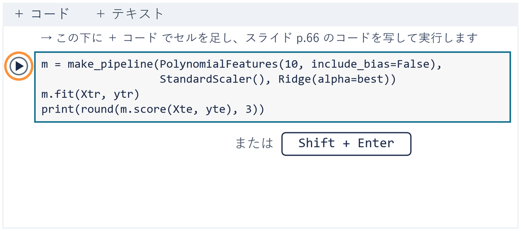

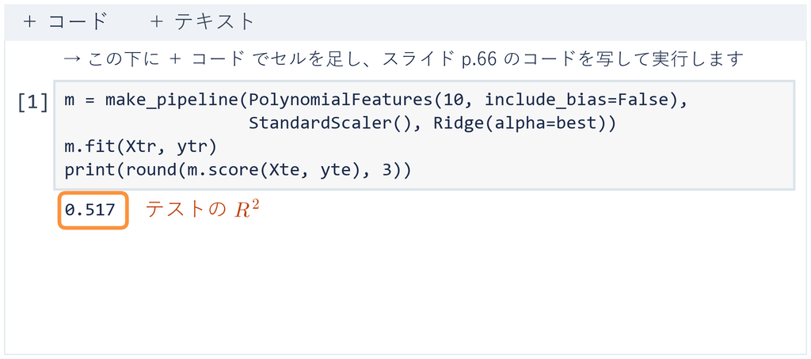

⏸ PAUSE 動画を止めて $2$ 分。`0.517` が出たら再生に戻る

## たしかめ テストで選び直した $\alpha$

たしかめ

テストの 9 年で $\alpha$ を選び直すと、テストの $R^2$ は 0.517 から？

**ⓐ** 上がる **ⓑ** 下がる **ⓒ** 変わらない

答えは **ⓐ** 0.520（$\alpha \approx 0.0030$）。20 個の候補にさっきの候補も入るので下がらない  
でもこれは 9 年に合わせた点。見ていない年への実力ではない

定義

**リーク** ＝ 検証用やテストの情報を  
学習や前処理（標準化など）に使うこと

- **標準化も同じ**：平均は訓練 27 年なら 3.53、36 年全体なら 3.58。`make_pipeline` は学ぶ側だけで決める

## ★ 2 つの対処の比較

同じ分け方（訓練 27 年・5 分割・くじ 42）で、曲げすぎの 2 つの対処を並べる

[figure not shown]

どちらの対処でも、見ていない年への当たりは 0.42 から 0.52 前後に戻る  
この分け方の CV の誤差では、罰金がわずかに小さい。差は小さい

テストの 0.521 と 0.517 を見て選び直さない。$\alpha$ は前に出てきた 13 列の $\alpha$ と比べない（データが違う）

## Ridge と Lasso の係数

罰金を係数の絶対値の和に替えると Lasso（コードは `Ridge` を `Lasso` に）

[figure not shown]

$\alpha = 0.01$ で Lasso は 10 本のうち 8 本が 0 になる。テストの $R^2$ は Ridge 0.512・Lasso 0.408  
今回は、$\alpha$ を 0.1 に強めると、使う列が 2 本から 1 本に減った（テスト 0.444）

0 は「この強さでは使わなかった」。関係が無いことの証明ではない  
※ Lasso のコードの $\alpha$ は、二乗誤差の和を 2 × 27 ＝ 54 で割る目盛り。同じ 0.01 でも強さは別

## エラスティックネットの罰金（参考）

定義

**エラスティックネット** ＝ Ridge と Lasso の罰金を混ぜた罰金  
`ElasticNet(alpha=0.01, l1_ratio=0.5)` `l1_ratio`：混ぜる割合

[figure not shown]

36 年の 10 次（$\alpha = 0.01$・割合 0.5）：0 は 6 本で、Ridge と Lasso の間。テストの $R^2$ は 0.427  
似た動きの列が並ぶときに使われる方法（失業率⁹ と失業率¹⁰ は形がそっくり）

## 第8回のまとめ

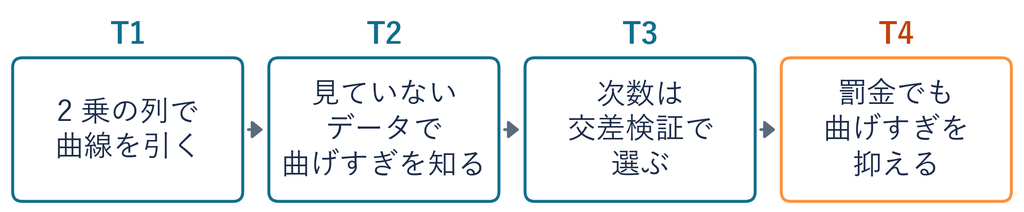

**列を作れば、曲がった関係も重回帰で表せる**  
**でも曲げるほど、見ていない相手に当たるとは限らない**  
曲げ方（次数）は、見ていないデータへの当たりで選ぶ  
曲げすぎは、次数を下げるか、罰金で抑える

10 次のテストの $R^2$：罰金なし 0.422 → 罰金あり 0.517（3 次に下げると 0.521）

見ていないデータで確かめる目は、ほかの手法でも同じ形で使う